# SIOP NLP Seminar 2019

Cory Kind

April 5, 2019

### Set-up

```r
#Clear your directory
rm(list = ls())

#Load relevant packages
library(tm)
library(ggplot2)
library(topicmodels)
library(dplyr)
library(stringi)
library(ggcorrplot)
library(ldatuning)
library(caret)
library(glmnet)
```

### Define helper functions

```r
#Input is a dataframe
#Output is the same dataframe in "corpus" format
create_corpus <- function(d_input) {
  ds <- DataframeSource(d_input)
  VCorpus(ds)
}

#Input is a corpus
#Output is a cleaned DTM
#Default paratmeters listed in function definition, can be overriden by specifying parameters when the function is called
create_cleaned_dtm <- function(docs,
                               convertToLower = TRUE,
                               stemWords = TRUE,
                               removePunc = TRUE,
                               removeStopwords = TRUE) {
  if (removePunc) docs <- tm_map(docs, removePunctuation, preserve_intra_word_dashes = TRUE)
  if (convertToLower) docs <- tm_map(docs, tolower)
  if (removeStopwords) docs <- tm_map(docs, removeWords, stopwords("english"))
  docs <- tm_map(docs, stripWhitespace)
  docs <- tm_map(docs, PlainTextDocument)

  if (stemWords) docs <- tm_map(docs, stemDocument)
  dtm <- DocumentTermMatrix(docs)
  dtm
}
```

### Load data, clean up scales

```r
#Note: Change to your own folder where the data is stored
setwd("C:/Users/ckind/Desktop")
nlp_data <- read.csv("NLP Tutorial Data.csv",
                     na.strings = c("Not Applicable","NA","select one"))

#Set factors
frequency_scale <- c("Never",
                     "Rarely",
                     "Occasionally",
                     "Sometimes",
                     "Frequently",
                     "Nearly Always",
                     "Always")
often_scale <- c("Never",
                "A few times a year",
                "Monthly",
                "A few times a month",
                "Every week",
                "A few times a week",
                "Every day")
agree_scale <- c("Strongly Disagree",
                 "Disagree",
                 "Somewhat Disagree",
                 "Neither Agree nor Disagree",
                 "Somewhat Agree",
                 "Agree",
                 "Strongly Agree")

#Work engagement scales
nlp_data$Answer.time_flies <- ordered(nlp_data$Answer.time_flies, levels = frequency_scale)
nlp_data$Answer.engrossed <- ordered(nlp_data$Answer.engrossed, levels = frequency_scale)
nlp_data$Answer.strong <- ordered(nlp_data$Answer.strong, levels = frequency_scale)
nlp_data$Answer.energized <- ordered(nlp_data$Answer.energized, levels = frequency_scale)
nlp_data$Answer.proud <- ordered(nlp_data$Answer.proud, levels = frequency_scale)
nlp_data$Answer.meaningful <- ordered(nlp_data$Answer.meaningful, levels = frequency_scale)
nlp_data$work_engagement_time2  = (as.numeric(nlp_data$Answer.time_flies) +
                            as.numeric(nlp_data$Answer.engrossed) +
                            as.numeric(nlp_data$Answer.strong) +
                            as.numeric(nlp_data$Answer.energized) +
                            as.numeric(nlp_data$Answer.proud) +
                            as.numeric(nlp_data$Answer.meaningful))/7
nlp_data$absorption_time2  = (as.numeric(nlp_data$Answer.time_flies) +
                            as.numeric(nlp_data$Answer.engrossed))/2

#Emotional exhaustion scales
nlp_data$Answer.frustrated <- ordered(nlp_data$Answer.frustrated, levels = often_scale)
nlp_data$Answer.burnedout <- ordered(nlp_data$Answer.burnedout, levels = often_scale)
nlp_data$Answer.fatigued <- ordered(nlp_data$Answer.fatigued, levels = often_scale)
nlp_data$emotional_exhaustion_time2  = (as.numeric(nlp_data$Answer.frustrated) +
                               as.numeric(nlp_data$Answer.burnedout) +
                               as.numeric(nlp_data$Answer.fatigued))/3

#Intent to stay scales
nlp_data$Answer.want_stay <- ordered(nlp_data$Answer.want_stay, levels = agree_scale)
nlp_data$Answer.intend_look <- ordered(nlp_data$Answer.intend_look, levels = agree_scale)
nlp_data$Answer.intend_stay <- ordered(nlp_data$Answer.intend_stay, levels = agree_scale)
#Note that intend to look is reversed
nlp_data$intend_stay_time2  = (as.numeric(nlp_data$Answer.want_stay) +
                                    8 - as.numeric(nlp_data$Answer.intend_look) +
                                    as.numeric(nlp_data$Answer.intend_stay))/3
```

### Exploratory data analysis of key variables

Histogram of Emotional Exhaustion

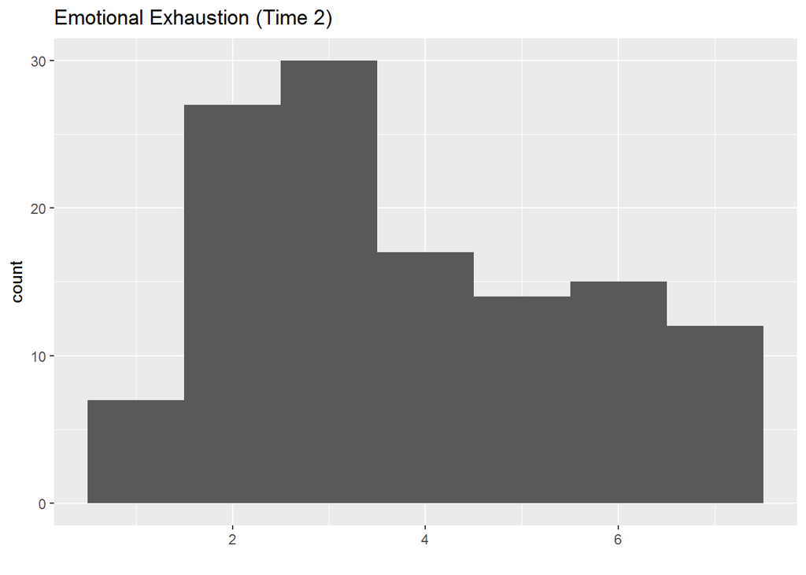

```r
ggplot(nlp_data, aes(x=emotional_exhaustion_time2)) + geom_histogram(binwidth = 1) + labs(title = "Emotional Exhaustion (Time 2)", x = "")
```

Histogram of Intent to Stay

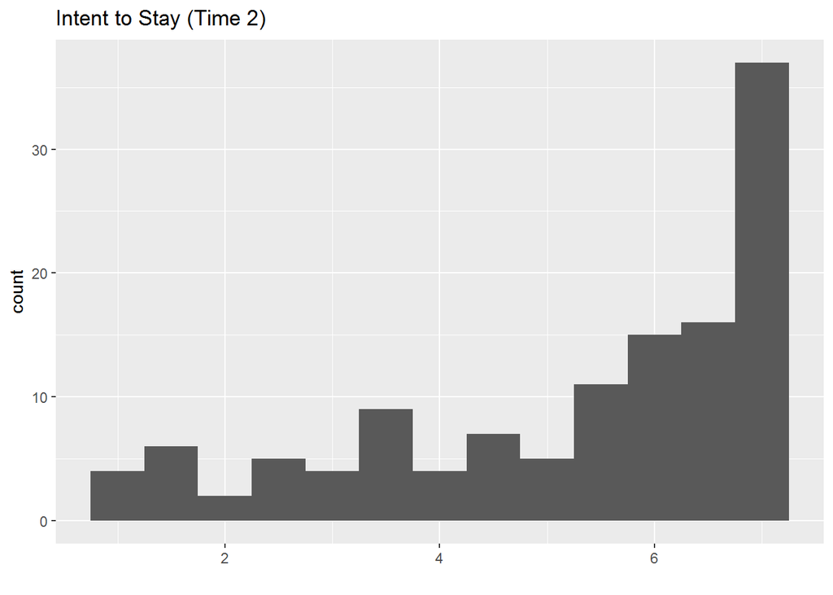

```r
ggplot(nlp_data, aes(x=intend_stay_time2)) + geom_histogram(binwidth = 0.5) + labs(title = "Intent to Stay (Time 2)", x = "")
```

Histogram of Work Engagement

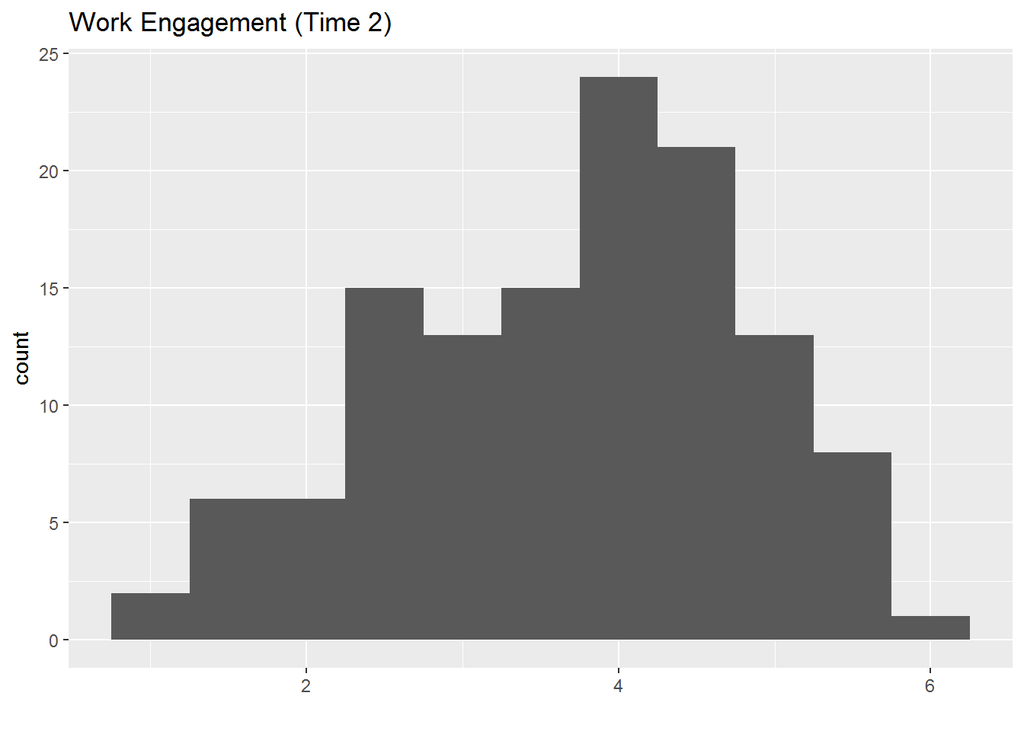

```r
ggplot(nlp_data, aes(x=work_engagement_time2)) + geom_histogram(binwidth = 0.5) + labs(title = "Work Engagement (Time 2)", x = "")
```

Checking correlation analysis of the different components of the work engagement scale

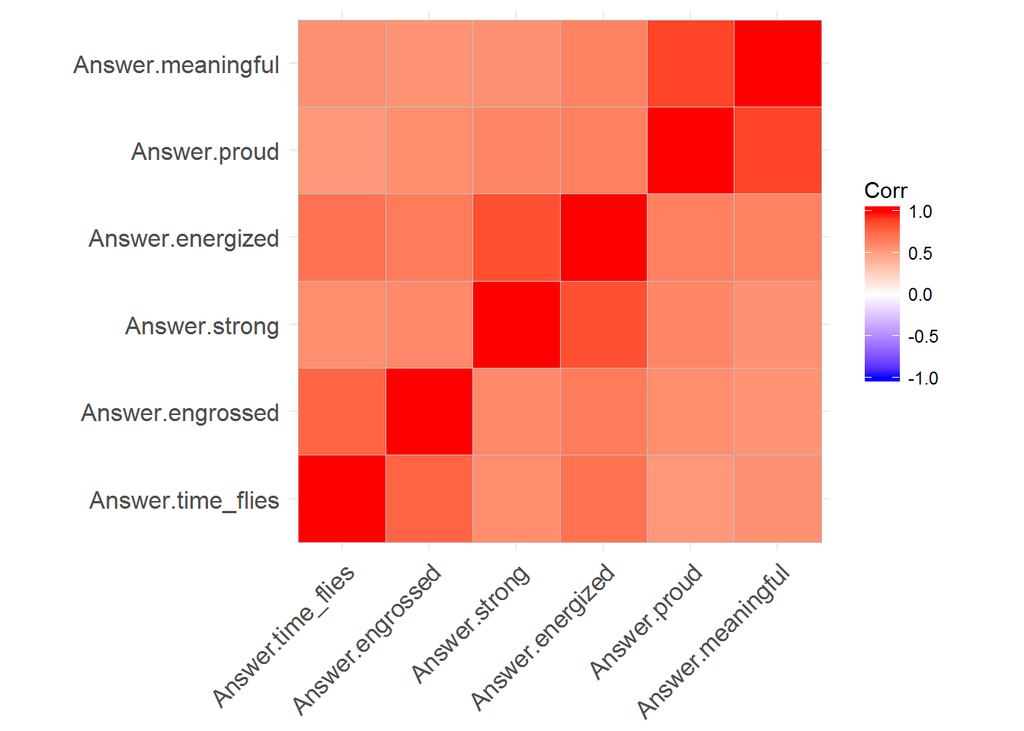

```r
ggcorrplot(cor(data.matrix(nlp_data[,c("Answer.time_flies",
                                       "Answer.engrossed", "Answer.strong",
                                       "Answer.energized", "Answer.proud",
                                       "Answer.meaningful")]),
                                        use = "pairwise.complete.obs"))
```

### Clean the text data and convert to DTM

Creating a cleaned corpus for the enjoyment text

```r
#Note that we're taking out cases where we have missing data
docs_enjoy <- data.frame(doc_id = nlp_data$WorkerId[!is.na(nlp_data$Answer.essay1)],
                         text = nlp_data$Answer.essay1[!is.na(nlp_data$Answer.essay1)],
                         stringsAsFactors = FALSE)

#Create corpus
corpus_enjoy <- create_corpus(docs_enjoy)

dtm_enjoy <- create_cleaned_dtm(corpus_enjoy)
dtm_enjoy
```

```
## <<DocumentTermMatrix (documents: 122, terms: 1228)>>
## Non-/sparse entries: 4315/145501
## Sparsity           : 97%
## Maximal term length: 15
## Weighting          : term frequency (tf)
```

To explore how parameters can be used to pipeline cleaning processes, here are examples of DTM outputs with different parameters

```r
create_cleaned_dtm(corpus_enjoy, removeStopwords = FALSE)
```

```
## <<DocumentTermMatrix (documents: 122, terms: 1303)>>
## Non-/sparse entries: 5863/153103
## Sparsity           : 96%
## Maximal term length: 16
## Weighting          : term frequency (tf)
```

```r
create_cleaned_dtm(corpus_enjoy, convertToLower = FALSE)
```

```
## <<DocumentTermMatrix (documents: 122, terms: 1255)>>
## Non-/sparse entries: 4459/148651
## Sparsity           : 97%
## Maximal term length: 15
## Weighting          : term frequency (tf)
```

```r
create_cleaned_dtm(corpus_enjoy, removeStopwords = FALSE, stemWords = FALSE)
```

```
## <<DocumentTermMatrix (documents: 122, terms: 1718)>>
## Non-/sparse entries: 6141/203455
## Sparsity           : 97%
## Maximal term length: 17
## Weighting          : term frequency (tf)
```

Exploring the DTM by looking at the most common words

Note that these frequencies are the the number of times the word is used in the corpus, NOT the number of people who used it. The DTM represents counts (1+) not a binary representation of whether the word was used at all (0/1).

```r
#EDA and additional optional cleaning steps to reduce the number of words
freq <- colSums(as.matrix(dtm_enjoy))

dtm_enjoy <- removeSparseTerms(dtm_enjoy, 0.99) #This drops terms that are very infrequently used
freq <- colSums(as.matrix(dtm_enjoy)) #Generates a frequency table

freq <- sort(freq, decreasing = TRUE)
freq[order(freq, decreasing = TRUE)][1:100] #100 most common words in the enjoyment text
```

```
##       work       like        job      peopl      enjoy        get
##        212        178        120         89         84         84
##       help       also        day       make        can       feel
##         78         72         65         64         59         53
##      thing       love       time        abl       good    problem
##         53         44         43         41         39         39
##        new    student     realli     differ       know      learn
##         38         37         36         35         32         32
##       well        see     someth       dont      think     custom
##         31         29         29         26         26         25
##       team      alway       come        lot       need     person
##         25         24         24         24         24         24
##       best       find       task      great        one       live
##         23         23         22         21         21         20
##   interact       just     someon      manag      offic        use
##         18         18         18         17         17         17
##   challeng       mani       will       year       deal      never
##         16         16         16         16         15         15
##       solv      teach       want      allow       even      everi
##         15         15         15         14         14         14
##       fact    flexibl       give       keep     actual     better
##         14         14         14         14         13         13
##     client     cowork       issu       life       look       much
##         13         13         13         13         13         13
##      skill    compani       hour     impact   opportun      posit
##         13         12         12         12         12         12
##        set    varieti        way       done    environ       home
##         12         12         12         11         11         11
##   interest      other       part    product    project    sometim
##         11         11         11         11         11         11
##        tri understand     around      daili       data   everyday
##         11         11         10         10         10         10
##      littl       long        may      place
##         10         10         10         10
```

### Unsupervised modeling

Identify the optimum number of topics for the enjoyment text using ldatuning package

```r
#Model parameters
#NOTE: Setting the seed effectively "freezes"" the randomness so that the analysis is the same across multiple runs of the code, that isn't a parameter to optimize
result_enjoy <- FindTopicsNumber(
  dtm_enjoy,
  topics = seq(from = 2, to = 10, by = 1),
  metrics = c("Griffiths2004", "CaoJuan2009", "Arun2010", "Deveaud2014"),
  method = "Gibbs",
  control = list(seed = 248),
  verbose = TRUE
)
```

```
## fit models... done.
## calculate metrics:
##   Griffiths2004... done.
##   CaoJuan2009... done.
##   Arun2010... done.
##   Deveaud2014... done.
```

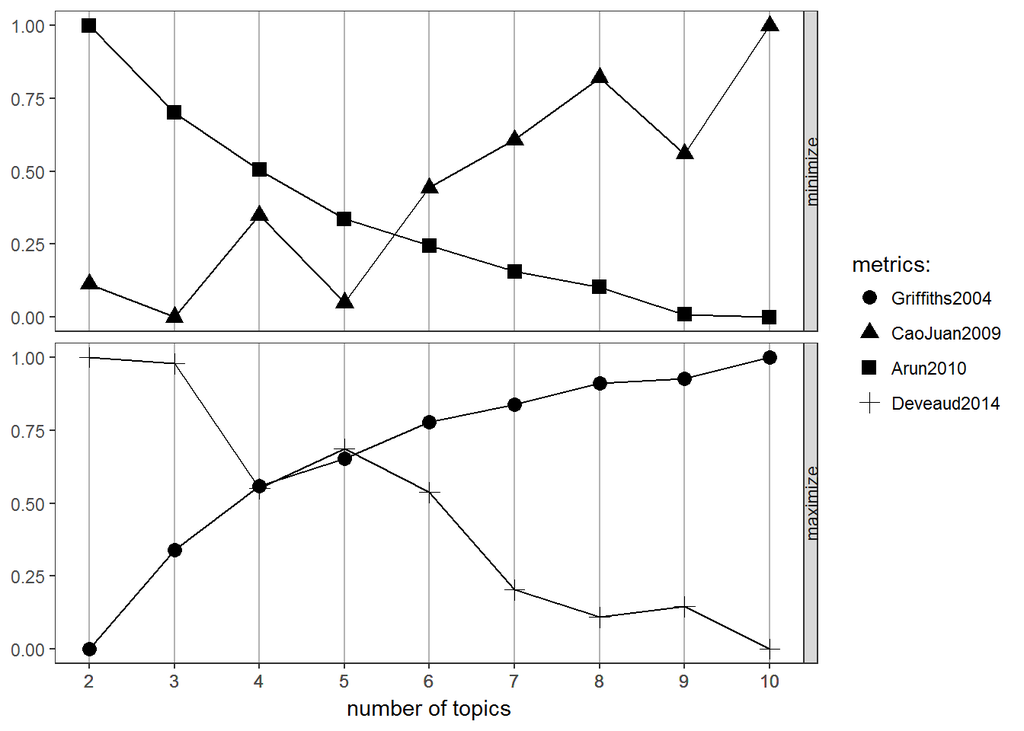

```r
FindTopicsNumber_plot(result_enjoy)
```

Repeat cleaning steps for the absorption text and identify the optimum number of topics using ldatuning package

```r
#Cleaning steps (mostly the same as above)
docs_absorption <- data.frame(doc_id = nlp_data$WorkerId[!is.na(nlp_data$Answer.essay2)],
                         text = nlp_data$Answer.essay2[!is.na(nlp_data$Answer.essay2)],
                         stringsAsFactors = FALSE)
corpus_absorption <- create_corpus(docs_absorption)
dtm_absorption <- create_cleaned_dtm(corpus_absorption, stemWords = FALSE)
dtm_absorption <- removeSparseTerms(dtm_absorption, 0.9) #Removing more sparse terms this time

result_absorption <- FindTopicsNumber(
  dtm_absorption,
  topics = seq(from = 2, to = 10, by = 1),
  metrics = c("Griffiths2004", "CaoJuan2009",
              "Arun2010", "Deveaud2014"),
  method = "Gibbs",
  control = list(seed = 248),
  verbose = TRUE
)
```

```
## fit models... done.
## calculate metrics:
##   Griffiths2004... done.
##   CaoJuan2009... done.
##   Arun2010... done.
##   Deveaud2014... done.
```

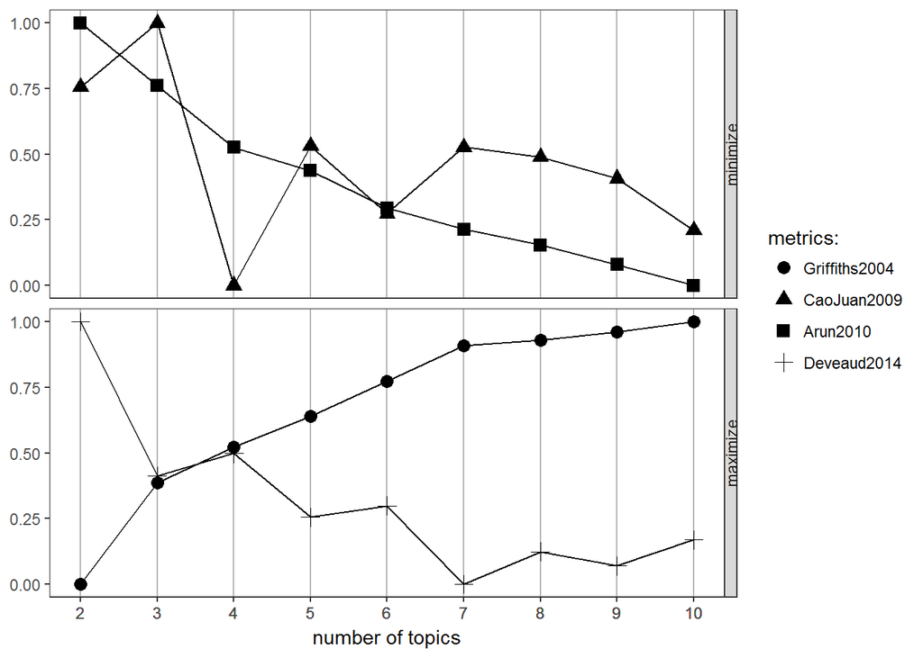

```r
FindTopicsNumber_plot(result_absorption)
```

### Supervised modeling

Predict absorption at time 2 given the text provided in the absorption prompt

```r
dtm_absorption <- create_cleaned_dtm(corpus_absorption, stemWords = FALSE)

#NOTE: Setting the sparsity term is a very brute-force way to remove terms. In a real project, there are better strategies for feature reduction (e.g., dictionary creation, PCA, stemming)
dtm_absorption <- removeSparseTerms(dtm_absorption, 0.8)

#Convert to matrix and add the target variable (absoprtion time 2)
absorption_matrix <- as.matrix(dtm_absorption)
absorption_matrix <- cbind(absorption_matrix, nlp_data$absorption_time2)

absorption_dataframe <- as.data.frame(absorption_matrix)
names(absorption_dataframe)[ncol(absorption_dataframe)] <- "absorption_time2"

fitControl <- trainControl(## 10-fold CV
  method = "cv",
  number = 10,
  savePredictions = TRUE
)

#Create linear regression
lreg <- caret::train(absorption_time2 ~., data = absorption_dataframe, method="lm", trControl=fitControl)

lreg
```

```
## Linear Regression
##
## 125 samples
##  28 predictor
##
## No pre-processing
## Resampling: Cross-Validated (10 fold)
## Summary of sample sizes: 114, 113, 111, 113, 113, 112, ...
## Resampling results:
##
##   RMSE      Rsquared   MAE
##   1.364596  0.1068917  1.107356
##
## Tuning parameter 'intercept' was held constant at a value of TRUE
```

```r
summary(lreg)
```

```
##
## Call:
## lm(formula = .outcome ~ ., data = dat)
##
## Residuals:
##      Min       1Q   Median       3Q      Max
## -3.03888 -0.65202  0.03105  0.78734  2.17581
##
## Coefficients:
##             Estimate Std. Error t value Pr(>|t|)
## (Intercept)  3.70689    0.30899  11.997  < 2e-16 ***
## can          0.06287    0.14366   0.438  0.66263
## day          0.15436    0.13314   1.159  0.24916
## days        -0.02123    0.15151  -0.140  0.88887
## distracted  -0.09127    0.22543  -0.405  0.68647
## dont        -0.32316    0.20397  -1.584  0.11640
## easy         0.40817    0.21447   1.903  0.06002 .
## feel        -0.08753    0.21403  -0.409  0.68350
## find        -0.16203    0.22217  -0.729  0.46758
## focus       -0.25261    0.17392  -1.452  0.14964
## get          0.07087    0.14500   0.489  0.62611
## goes         0.40901    0.26531   1.542  0.12645
## job          0.29075    0.17538   1.658  0.10062
## like         0.27227    0.16238   1.677  0.09685 .
## lot         -0.06595    0.22043  -0.299  0.76544
## much        -0.13789    0.26005  -0.530  0.59717
## passes       0.10126    0.19053   0.531  0.59633
## quickly      0.14179    0.18824   0.753  0.45315
## really      -0.12774    0.19419  -0.658  0.51224
## slowly      -0.64757    0.22662  -2.858  0.00523 **
## something    0.06466    0.17131   0.377  0.70669
## task        -0.20926    0.26472  -0.790  0.43119
## tasks       -0.31691    0.23090  -1.372  0.17311
## things      -0.38607    0.21118  -1.828  0.07064 .
## time         0.21094    0.10232   2.062  0.04196 *
## times       -0.17749    0.17413  -1.019  0.31065
## will         0.01071    0.16751   0.064  0.94913
## work         0.06886    0.07875   0.874  0.38403
## working      0.19200    0.14790   1.298  0.19733
## ---
## Signif. codes:  0 '***' 0.001 '**' 0.01 '*' 0.05 '.' 0.1 ' ' 1
##
## Residual standard error: 1.167 on 96 degrees of freedom
## Multiple R-squared:  0.3553, Adjusted R-squared:  0.1672
## F-statistic: 1.889 on 28 and 96 DF,  p-value: 0.01212
```

```r
varImp(lreg)
```

```
## lm variable importance
##
##   only 20 most important variables shown (out of 28)
##
##         Overall
## slowly   100.00
## time      71.50
## easy      65.83
## things    63.15
## like      57.73
## job       57.05
## dont      54.42
## goes      52.89
## focus     49.70
## tasks     46.84
## working   44.18
## day       39.21
## times     34.20
## work      29.01
## task      26.01
## quickly   24.67
## find      23.82
## really    21.26
## passes    16.73
## much      16.69
```

### Types of Validity

Correlate predicted scores with actual absorption numbers (construct validity)

```r
predictions <- predict(lreg, newdata=absorption_dataframe)

cor(as.numeric(predictions), as.numeric(nlp_data$absorption_time2))
```

```
## [1] 0.5960438
```

Predicted scores from previous step correlated with time 2 intent to stay (criterion validity)

```r
cor(as.numeric(predictions), as.numeric(nlp_data$intend_stay_time2))
```

```
## [1] 0.2709001
```

Analysis of the results of the topic models on the absorption text and enjoyment text (content validity)

```r
#Absorption text
k <- 4 #Number of topics you want to be looking for

ldaOut <-LDA(dtm_absorption, k, method="Gibbs", control=list(seed = 248, best=TRUE)) #Run the model
ldaOut.terms <- as.matrix(terms(ldaOut,10))
ldaOut.terms
```

```
##       Topic 1  Topic 2      Topic 3      Topic 4
##  [1,] "time"   "time"       "work"       "quickly"
##  [2,] "like"   "get"        "easy"       "working"
##  [3,] "slowly" "distracted" "times"      "day"
##  [4,] "passes" "focus"      "really"     "can"
##  [5,] "feel"   "will"       "can"        "dont"
##  [6,] "lot"    "days"       "focus"      "something"
##  [7,] "task"   "much"       "day"        "job"
##  [8,] "days"   "job"        "much"       "things"
##  [9,] "find"   "passes"     "distracted" "tasks"
## [10,] "will"   "can"        "feel"       "goes"
```

Enjoyment

```r
#Enjoyment text
k <- 3 #Number of topics you want to be looking for

ldaOut <-LDA(dtm_enjoy, k, method="Gibbs", control=list(seed = 248, best=TRUE)) #Run the model
ldaOut.terms <- as.matrix(terms(ldaOut,10))
ldaOut.terms
```

```
##       Topic 1 Topic 2   Topic 3
##  [1,] "work"  "like"    "also"
##  [2,] "job"   "peopl"   "enjoy"
##  [3,] "thing" "get"     "make"
##  [4,] "time"  "help"    "day"
##  [5,] "well"  "can"     "love"
##  [6,] "dont"  "feel"    "differ"
##  [7,] "team"  "abl"     "new"
##  [8,] "lot"   "good"    "someth"
##  [9,] "learn" "student" "think"
## [10,] "great" "realli"  "custom"
```

Correlation between time 2 quant absorption and time 2 quant intent to stay scores

```r
cor(nlp_data$absorption_time2, nlp_data$intend_stay_time2,
    use = "pairwise.complete.obs")
```

```
## [1] 0.5047445
```